# PHYS 210 Day 09

### 2026 - 10 - 14

Agenda:

1. Announcements: **Test 2 window open until Sat Oct 17** (Practice Test 2: retake it as often as you like) · **Test 3 (Days 09–10 + dictionaries): Mon Oct 26 – Fri Oct 30** · Practice Test 3 opens Mon Oct 19
2. Reading 09 recap, Q&A and polling questions: Monte-Carlo methods 1
3. Group Worksheet 09

## Reading recap, Q&A and polling questions

Random numbers first, then Monte-Carlo estimates, then seeds

## Reading recap: pseudorandom numbers

- An algorithm makes the numbers: they are **deterministic**, but they behave like true random numbers
- The **seed** is the starting state: `np.random.seed(8000)` followed by `np.random.rand(5)` gives the same 5 numbers every time
- No seed: NumPy takes a starting state from the computer (for example the clock), so every run is different

### The `np.random` toolbox

| Call | Gives |
| --- | --- |
| `np.random.rand(5)` | 5 floats in [0, 1) |
| `np.random.uniform(0, 5, 4)` | 4 floats in [0, 5) |
| `np.random.randint(1, 10, size=5)` | 5 integers from 1 to 9: **high is excluded** |
| `np.random.choice([7, 8, 9], size=5)` | 5 picks, with replacement (`p=` sets the weights) |
| `np.random.shuffle(arr)` | shuffles `arr` in place |
| `np.random.randn(10000)` | standard normal: mean 0, standard deviation 1 |
| `np.random.normal(loc=10, scale=3, size=1000)` | normal with mean 10, standard deviation 3 |

`size` can be a tuple: `size=(1000, 2)` gives an array with shape `(1000, 2)`

### Other random-number libraries

- `random` module: `random.uniform(a, b)`
- `numpy.random`: `np.random.uniform(a, b, size)` (what we use)
- `secrets` module: cryptographically secure random numbers and strings
- `scipy.stats`: a huge number of special statistical distributions

**Poll Q1:** What does this print?

```python
import numpy as np
r = np.random.randint(1, 7, size=(1000, 2))
print(r.shape, r.min(), r.max())
```

A) `(1000, 2) 1 7`  
B) `(1000, 2) 1 6`  
C) `(2, 1000) 1 6`  
D) `(2000,) 1 6`  
E) `(1000, 2) 0 6`

## The Monte-Carlo recipe

1. Draw random inputs
2. Do a deterministic calculation on each input
3. Aggregate the results into one estimate

$\pi$ from the reading: points uniform in the unit square; the fraction inside the quarter circle is about $\pi/4$, so $\pi \approx 4\,N_{in}/N_{tot}$

Any area: (fraction of points that meet the condition) × (area of the box)

Good random points are uniform, uncorrelated and many: the error shrinks like $1/\sqrt{N}$

### Typical example: $\pi$ from a square

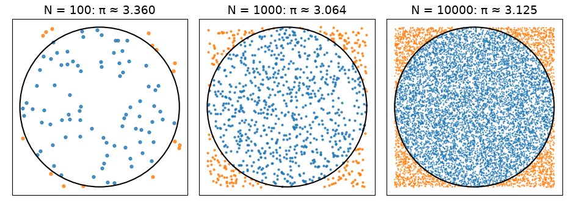

- Fraction of points inside the circle ≈ $\pi/4$, so $\pi \approx 4 \times$ fraction
- More points: a better estimate, but slowly

## Monte-Carlo volume of a sphere

The box is the cube $-1 \le x, y, z < 1$. Each row of `r` is one random point $(x, y, z)$.

```python
import numpy as np
import matplotlib.pyplot as plt
r = np.random.uniform(-1, 1, (5, 3))
r
```

### Points inside and outside the sphere

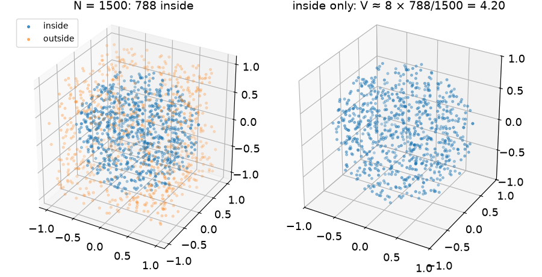

```python
r = np.random.uniform(-1, 1, (1500, 3))
inside = r[:, 0]**2 + r[:, 1]**2 + r[:, 2]**2 <= 1

ax = plt.figure().add_subplot(projection='3d')
ax.scatter(r[inside, 0], r[inside, 1], r[inside, 2], s=6, c='tab:blue', label='inside')
ax.scatter(r[~inside, 0], r[~inside, 1], r[~inside, 2], s=6, c='tab:orange', alpha=0.5, label='outside')
ax.set_box_aspect((1, 1, 1))
ax.legend()
plt.show()
```

**Poll Q2:** Which line estimates the volume of the sphere with radius 1?

```python
import numpy as np
r = np.random.uniform(-1, 1, (10000, 3))
inside = r[:, 0]**2 + r[:, 1]**2 + r[:, 2]**2 <= 1
frac = np.sum(inside) / len(r)
```

A) `4/3 * np.pi * frac`  
B) `8 * frac`  
C) `2 * frac`  
D) `frac / 8`  
E) `frac / 2`

## What is Monte-Carlo?

- Use **random samples** to compute a number you could, in principle, compute exactly
- Recipe: random inputs → a simple calculation on each → average
- Two kinds:
  - **Estimate a number**: a volume, an integral, a probability (the sphere)
  - **Simulate a random process**: radioactive decay, diffusion, a photon in tissue, a neutron in a reactor
- The answer comes with an **error bar**, and the error bar shrinks as you add samples

## Where is it used?

- **Particle and nuclear physics:** detector simulation (Geant4, from CERN; also used at TRIUMF)
- **Medical physics:** radiation-therapy dose (EGSnrc, from the National Research Council Canada), PET and SPECT imaging
- **Statistical physics:** magnets and phase transitions (Ising model, Metropolis algorithm, 1953)
- **Astrophysics, climate:** light through stars, dust and clouds; weather ensembles
- **Outside physics:** film rendering (path tracing), finance (option prices), AlphaGo (Monte-Carlo tree search)

## Monte-Carlo integral of sin x: an AI answer — critique it

**Q:** Can you go over the sin(x) Monte-Carlo solution?

The prompt: *"python monte carlo integral of sin from 0 to pi"*. The answer said:

1. Generate random points (x, y) where x is between 0 and π and y is between 0 and 1.
2. Count the number of points that lie below the curve y = sin(x).
3. The ratio of the points below the curve to the total number of points, multiplied by the area of the bounding box (π × 1 = π), gives an approximation of the integral.

"The more samples you use, the closer the estimate will be to the actual value. However, convergence can be slow."

### What the AI's recipe does

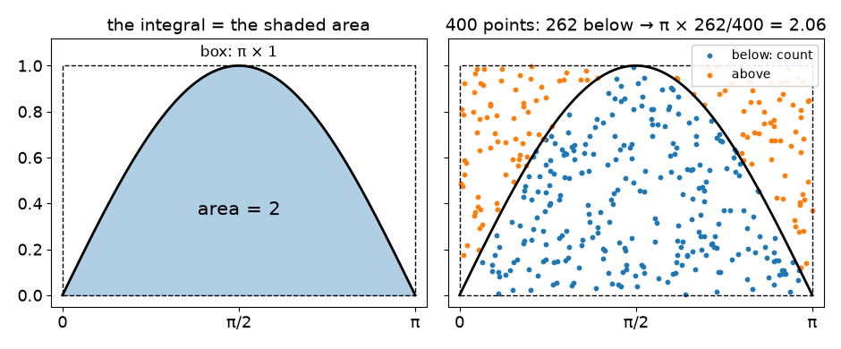

- Integral = shaded area = 2; box = $\pi \times 1$
- Area ≈ (fraction of points below the curve) × (area of the box)

### The AI code

```
import numpy as np

def monte_carlo_integration_sin(n_samples=100000):
    # Generate random x values between 0 and pi
    x = np.random.uniform(0, np.pi, n_samples)
    # Generate random y values between 0 and 1
    y = np.random.uniform(0, 1, n_samples)
    # Check how many points lie below y = sin(x)
    below_curve = y < np.sin(x)
    # Compute the ratio of points below the curve to total points
    ratio = np.sum(below_curve) / n_samples
    # The area of the bounding box is pi
    area_box = np.pi
    # Return the approximate integral
    return ratio * area_box

# Estimate the integral
integral_estimate = monte_carlo_integration_sin()
print(f"Monte Carlo estimate of the integral: {integral_estimate}")
# The actual value of the integral of sin(x) from 0 to pi is 2
print(f"Actual value: 2")
```

### Run it, then change `n_samples`

```python
import numpy as np

def mc_sin(n_samples=100000):
    x = np.random.uniform(0, np.pi, n_samples)
    y = np.random.uniform(0, 1, n_samples)  # box: pi wide, 1 tall
    below_curve = y < np.sin(x)
    ratio = np.sum(below_curve) / n_samples
    return ratio * np.pi

print(f"MC estimate: {mc_sin():.4f}, exact: 2")
```

## Do you trust it? Ways to probe the AI code

1. **Known answers:** integrals you can do by hand
2. **Many runs:** is the average right? how big is the scatter?
3. **Write a test:** `assert` with a tolerance from the scatter
4. **Change the bounds:** $[0, 2\pi]$, $[\pi, 2\pi]$
5. **Change the function:** is the box still tall enough?
6. **Another method:** mean value, `scipy.integrate.quad`
7. **Edge cases:** `n_samples=1`, `n_samples=0`
8. **Run longer:** 100× the points → 10× smaller scatter (next poll)

### 1. Known answers

```python
def mc_integral(f, a, b, ymax, n):
    x = np.random.uniform(a, b, n)
    y = np.random.uniform(0, ymax, n)
    return (b - a) * ymax * np.mean(y < f(x))

def square(x):
    return x**2

np.random.seed(1)
tests = [(square, 0, 1, 1, 1/3),
         (np.sin, 0, np.pi, 1, 2),
         (np.exp, 0, 1, np.e, np.e - 1)]
for f, a, b, ymax, exact in tests:
    print(f"{mc_integral(f, a, b, ymax, 100_000):.4f}   exact {exact:.4f}")
```

```
0.3334   exact 0.3333
1.9967   exact 2.0000
1.7196   exact 1.7183
```

### 2. Many runs: average and scatter

```python
np.random.seed(2)
runs = []
for i in range(200):
    runs.append(mc_sin(10_000))
print(f"mean {np.mean(runs):.4f}   std {np.std(runs):.4f}")
```

```
mean 2.0005   std 0.0146
```

The average is right (no bias); one run at N = 10 000 is good to about ±0.015

### 3. Write a test

```python
est = mc_sin(1_000_000)
sigma = 0.016 / 10      # 1/sqrt(N): 100x the points of P2
assert abs(est - 2) < 5 * sigma, est
print("passed:", est)
```

```
passed: 2.0012...
```

Tolerance from the scatter: 5σ fails by chance about once in 2 million runs

### 4. Change the bounds

```python
def mc_sin_ab(a, b, n=100_000):    # the AI code, bounds as arguments
    x = np.random.uniform(a, b, n)
    y = np.random.uniform(0, 1, n)
    return (b - a) * np.mean(y < np.sin(x))

np.random.seed(4)
print(f"[0, pi]   {mc_sin_ab(0, np.pi):.3f}   exact  2")
print(f"[0, 2pi]  {mc_sin_ab(0, 2*np.pi):.3f}   exact  0")
print(f"[pi, 2pi] {mc_sin_ab(np.pi, 2*np.pi):.3f}   exact -2")
```

```
[0, pi]   1.993   exact  2
[0, 2pi]  2.014   exact  0
[pi, 2pi] 0.000   exact -2
```

**Fails:** points with $0 \le y < 1$ cannot count area below the axis

### 5. Change the function: is the box tall enough?

```python
def two_sin(x):                   # exact integral on [0, pi]: 4
    return 2 * np.sin(x)

np.random.seed(5)
print(f"box 1 tall: {mc_integral(two_sin, 0, np.pi, 1, 100_000):.3f}")
print(f"box 2 tall: {mc_integral(two_sin, 0, np.pi, 2, 100_000):.3f}")
```

```
box 1 tall: 2.632
box 2 tall: 4.007
```

**Fails silently** when the curve leaves the box: the points never see the top

### 6. Another method

```python
from scipy.integrate import quad
np.random.seed(6)
x = np.random.uniform(0, np.pi, 10_000)
print("hit-or-miss:", mc_sin(10_000))
print("mean value: ", np.pi * np.mean(np.sin(x)))
print("quad:       ", quad(np.sin, 0, np.pi)[0])
```

```
hit-or-miss: 2.0266...
mean value:  1.9944...
quad:        2.0
```

Mean value: $(b-a) \times$ mean of $f(x)$: no box, smaller scatter (0.0097 vs 0.0155 at N = 10 000)

### 7. Edge cases

```python
np.random.seed(7)
print(mc_sin(1))
print(mc_sin(0))
```

```
0.0
nan    RuntimeWarning: invalid value encountered in scalar divide
```

With 1 point the answer is 0 or π; with 0 points, 0/0

**Poll Q3:** With N = 10 000 points, the Monte-Carlo estimate of $\int_0^\pi \sin x\,dx$ scatters by about 0.016 from run to run. About how many points do you need for a scatter of about 0.0016?

A) 20 000  
B) 100 000  
C) 1 000 000  
D) 10 000 000  
E) 100 000 000

## Watch the estimate improve

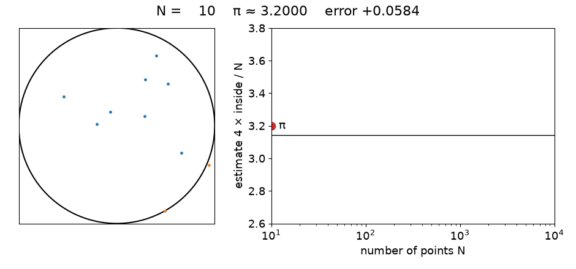

```python
from ipywidgets import interact

pts = np.random.uniform(-1, 1, (10_000, 2))
inside = pts[:, 0]**2 + pts[:, 1]**2 <= 1
est = 4 * np.cumsum(inside) / np.arange(1, 10_001)

def show(N=100):
    fig, (ax1, ax2) = plt.subplots(1, 2, figsize=(10, 4.5))
    ax1.scatter(pts[:N][inside[:N], 0], pts[:N][inside[:N], 1], s=3)
    ax1.scatter(pts[:N][~inside[:N], 0], pts[:N][~inside[:N], 1], s=3)
    ax1.set_aspect('equal')
    ax2.semilogx(np.arange(1, N + 1), est[:N])
    ax2.plot(N, est[N - 1], 'ro')
    ax2.axhline(np.pi, color='k')
    ax2.set_xlim(1, 10_000); ax2.set_ylim(2.5, 4)
    plt.show()

interact(show, N=(10, 10_000, 10));
```

### 20 runs: a funnel

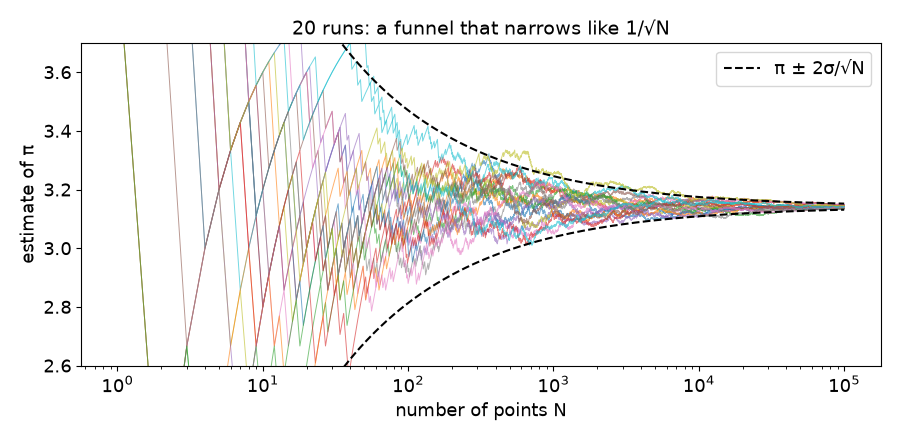

- Every run starts wild and closes in on $\pi$
- Width of the funnel: $\pm 2\sigma/\sqrt{N}$

### 100× more points → 10× narrower

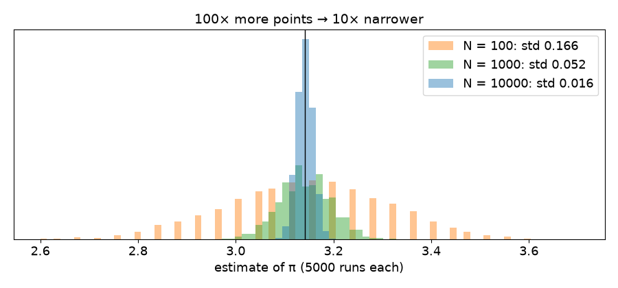

### Why $1/\sqrt{N}$?

- Each point is a coin flip: inside with probability $p = \pi/4$
- After $N$ points: hits ≈ $Np \pm \sqrt{Np(1-p)}$ (like a random walk: spread grows as $\sqrt{N}$)
- Estimate $= 4 \times \text{hits}/N$:
  - signal grows like $N$, noise like $\sqrt{N}$
  - error $= \sigma/\sqrt{N}$, with $\sigma = 4\sqrt{p(1-p)} \approx 1.6$
- Each extra digit costs **100×** more points

**Q.** I was confused by the last code in the reading. Could we go over it together?

**Q.** I don't really understand when to use the `<` symbol, or how it works here.

**A.** Preclass 9.5 (radioactive decay): one random number per atom. `np.random.rand(N) < p` is `True` where that atom decays.

```python
import numpy as np
u = np.random.rand(10)
print(u < 0.3)
print(np.sum(u < 0.3))
```

## Is it random? Which one is a real coin?

**A:** `HTHHTHTTHTHHTTHTHTHHTHTTHHTHTTHTHHTHTTHT`

**B:** `TTHTHTTHTHHHTHHHHHHTHTTHHHHTHTTTHHTHTTTH`

### How a pseudorandom generator works

An old, well-known generator: the [linear congruential generator](https://en.wikipedia.org/wiki/Linear_congruential_generator). The seed is the first `x`.

```python
def lcg(seed, n):
    a, c, m = 1103515245, 12345, 2**31
    x = seed
    out = []
    for i in range(n):
        x = (a * x + c) % m
        out.append(round(x / m, 4))
    return out

print(lcg(1, 4))
print(lcg(1, 4))
print(lcg(2, 4))
```

## Structure in the sequence: plot $x_{n+1}$ against $x_n$

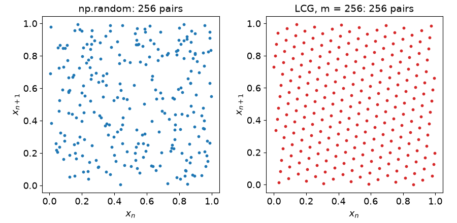

- An LCG puts pairs (and triples) on a **lattice**
- Small $m$ makes it obvious; large $m$ only hides it

```python
def lcg_int(seed, n, a=137, c=187, m=256):
    x, out = seed, []
    for i in range(n):
        x = (a * x + c) % m
        out.append(x)
    return np.array(out)

u = lcg_int(1, 256) / 256
plt.scatter(u[:-1], u[1:], s=10)
plt.gca().set_aspect('equal')
plt.show()
```

### RANDU (IBM, 1960s): triples on 15 planes

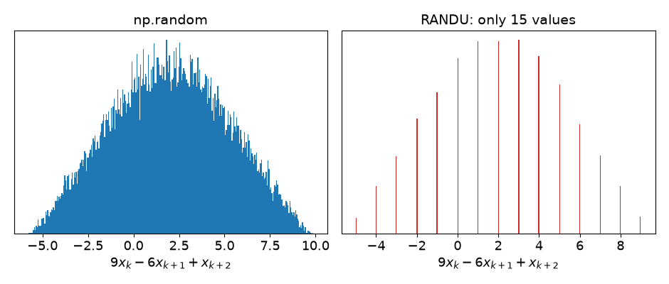

- $x_{k+1} = 65539\, x_k \bmod 2^{31}$, widely used for years
- Always $x_{k+2} = 6x_{k+1} - 9x_k$ (mod $2^{31}$): every triple lies on one of **15** planes

## Seeds

**Q:** What does the seed number do?

**Poll Q4:** What does this print?

```python
import numpy as np
np.random.seed(42)
a = np.random.rand(3)
b = np.random.rand(3)
np.random.seed(42)
c = np.random.rand(3)
print(np.array_equal(a, b), np.array_equal(a, c))
```

A) `True True`  
B) `False True`  
C) `True False`  
D) `False False`

**Poll Q5:** What does this print?

```python
import numpy as np

def one_run(n):
    np.random.seed(210)
    return np.mean(np.random.rand(n))

runs = []
for i in range(5):
    runs.append(one_run(1000))
print(round(np.std(runs), 4))
```

A) `0.0`  
B) about `0.01`  
C) about `0.29`  
D) a different value on every run  
E) Error

## When generators fail: a short period

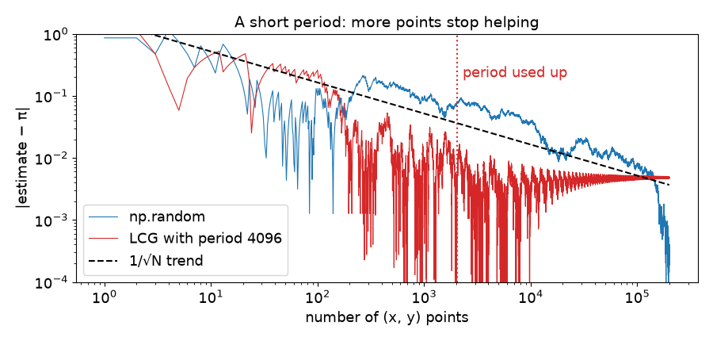

- Period 4096 → only 2048 different $(x, y)$ points, then the same points again
- NumPy's generators: period $2^{19937}-1$ (Mersenne Twister), $2^{128}$ (PCG64)

### Predictable = exploitable

- A seed from the clock: try every second of the day

```python
# dealer: shuffles with the clock as seed
seed = 49_327                    # e.g. seconds since midnight
deck = np.random.default_rng(seed).permutation(52)
seen = deck[:5]                  # the 5 cards you can see

# attacker: try every second of the day
for s in range(86_400):
    if np.array_equal(np.random.default_rng(s).permutation(52)[:5], seen):
        print('seed', s, '→ next cards', np.random.default_rng(s).permutation(52)[5:10])
        break
print('dealer has', deck[5:10])
```

```
seed 49327 → next cards [ 4 45 25 27 33]
dealer has [ 4 45 25 27 33]
```

Under a second on a laptop

## What to use

- **Simulations, this course:** `np.random` (Mersenne Twister) is fine; newer code: `rng = np.random.default_rng(seed)`
- **Anything secret** (passwords, tokens, games with money): `secrets`
- **True randomness:** physics! Radioactive decay, thermal noise, a wall of lava lamps

> "Anyone who considers arithmetical methods of producing random digits is, of course, in a state of sin." (John von Neumann, 1951)

### Homework 08: what the submissions showed

Most of you got all six "passed" lines. Three things the asserts did not check:

- **The stop condition of a `while`:** "until fewer than 10 remain" means keep going `while n >= 10`. `while n > 10` also gave 7 here, but only because `n` never equals 10. Start at 1280: `n > 10` stops at 10 after 7 hours, the correct answer is 8 hours
- **Read the task, not only the asserts:** Task 1 asked for the key `mass_MeV` and the f-string sentence `The muon has mass 105.66 MeV.` The asserts checked only `name` and `lifetime_us`
- **One pass over the data:** in Task 5, one loop `for det, E in events:` updates `total` and `count` together. Unpack the tuple instead of `ev[0]`, `ev[1]`

# The rest of today, and before you leave

- **Group Worksheet 09** (Monte-Carlo: area under a curve, scatter vs N, seeds; Plinko optional): link on Canvas; one driver per task, swap each task; checkpoint with a TA when done
- **Homework 09** due Mon Oct 19, 9:00 am. **Restart Kernel and Run All Cells before you export**
- **Preclass 10 (fitting)** due Mon Oct 19, 9:00 am
- **Test 2** window open until Sat Oct 17 (ORCA) · **Test 3** (Days 09–10 + dictionaries) Mon Oct 26 – Fri Oct 30 · Practice Test 3 opens Mon Oct 19